# **ASSIGNMENT 1 - End-to-End Machine Learning Project**

### **Eunice Worifah**

*Use Case:* *The aim of this project is to use Machine Learning to help an auto insurance company predict the Customer Lifetime Value (CLV) of a customer based on the customer's attributes (e.g. income, level of education, gender, etc...)*

# Setup

```python
# Python ≥3.5 is required
import sys
assert sys.version_info >= (3, 5)

# Scikit-Learn ≥0.20 is required
import sklearn
assert sklearn.__version__ >= "0.20"

# Common imports
import numpy as np
import os
import pandas as pd

# To plot pretty figures
%matplotlib inline
import matplotlib as mpl
import matplotlib.pyplot as plt
mpl.rc('axes', labelsize=14)
mpl.rc('xtick', labelsize=12)
mpl.rc('ytick', labelsize=12)

# Where to save the figures
PROJECT_ROOT_DIR = "."
CHAPTER_ID = "end_to_end_project"
IMAGES_PATH = os.path.join(PROJECT_ROOT_DIR, "images", CHAPTER_ID)
os.makedirs(IMAGES_PATH, exist_ok=True)

def save_fig(fig_id, tight_layout=True, fig_extension="png", resolution=300):
    path = os.path.join(IMAGES_PATH, fig_id + "." + fig_extension)
    print("Saving figure", fig_id)
    if tight_layout:
        plt.tight_layout()
    plt.savefig(path, format=fig_extension, dpi=resolution)

# Ignore useless warnings (see SciPy issue #5998)
import warnings
warnings.filterwarnings(action="ignore")
```

# Get the data

```python
import urllib

url = "https://raw.githubusercontent.com/euniceworifah/Customer_Lifetime_Value/main/CLVdata2.csv"
clv = pd.read_csv(url)
```

#### DATA DESCRIPTION

*Target Variable:*

- Customer Lifetime Value

*Categorical Independent Variables:*

- State
- Coverage
- Education
- Employment Status
- Gender
- Location Code
- Marital Status
- Policy Type
- Policy
- Renew Offer Type
- Sales Channel
- Vehicle Class
- Vehicle Size

*Continuous Independent Variables:*

- Income
- Monthly Premium Auto
- Months Since Last Claim
- Months Since Policy Inception
- Number of Open Complaints
- Number of Policies
- Total Claim Amount

```python
clv.head()
```

|  | State | Customer Lifetime Value | Coverage | Education | EmploymentStatus | Gender | Income | Location Code | Marital Status | Monthly Premium Auto | ... | Months Since Policy Inception | Number of Open Complaints | Number of Policies | Policy Type | Policy | Renew Offer Type | Sales Channel | Total Claim Amount | Vehicle Class | Vehicle Size |
| --- | --- | --- | --- | --- | --- | --- | --- | --- | --- | --- | --- | --- | --- | --- | --- | --- | --- | --- | --- | --- | --- |
| 0 | Washington | 2763.519279 | Basic | Bachelor | Employed | F | 56274.0 | Suburban | Married | 69 | ... | 5 | 0 | 1 | Corporate Auto | Corporate L3 | Offer1 | Agent | 384.811147 | Two-Door Car | Medsize |
| 1 | Arizona | 6979.535903 | Extended | Bachelor | Unemployed | F | NaN | Suburban | Single | 94 | ... | 42 | 0 | 8 | Personal Auto | Personal L3 | Offer3 | Agent | 1131.464935 | Four-Door Car | Medsize |
| 2 | Nevada | 12887.431650 | Premium | Bachelor | Employed | F | 48767.0 | Suburban | Married | 108 | ... | 38 | 0 | 2 | Personal Auto | Personal L3 | Offer1 | Agent | 566.472247 | Two-Door Car | Medsize |
| 3 | California | 7645.861827 | Basic | Bachelor | Unemployed | M | NaN | Suburban | Married | 106 | ... | 65 | 0 | 7 | Corporate Auto | Corporate L2 | Offer1 | Call Center | 529.881344 | SUV | Medsize |
| 4 | Washington | 2813.692575 | Basic | Bachelor | Employed | M | 43836.0 | Rural | Single | 73 | ... | 44 | 0 | 1 | Personal Auto | Personal L1 | Offer1 | Agent | 138.130879 | Four-Door Car | Medsize |

5 rows × 21 columns

```python
import pandas_profiling

#Generate a HTML report
profile = clv.profile_report(title='Pandas Profiling Report')
#profile

profile.to_file(output_file="profile_report_output.html")
```

```python
clv.info()
```

```
<class 'pandas.core.frame.DataFrame'>
RangeIndex: 9134 entries, 0 to 9133
Data columns (total 21 columns):
 #   Column                         Non-Null Count  Dtype
---  ------                         --------------  -----
 0   State                          9134 non-null   object
 1   Customer Lifetime Value        9134 non-null   float64
 2   Coverage                       9134 non-null   object
 3   Education                      9134 non-null   object
 4   EmploymentStatus               9134 non-null   object
 5   Gender                         9134 non-null   object
 6   Income                         6817 non-null   float64
 7   Location Code                  9134 non-null   object
 8   Marital Status                 9134 non-null   object
 9   Monthly Premium Auto           9134 non-null   int64
 10  Months Since Last Claim        9134 non-null   int64
 11  Months Since Policy Inception  9134 non-null   int64
 12  Number of Open Complaints      9134 non-null   int64
 13  Number of Policies             9134 non-null   int64
 14  Policy Type                    9134 non-null   object
 15  Policy                         9134 non-null   object
 16  Renew Offer Type               9134 non-null   object
 17  Sales Channel                  9134 non-null   object
 18  Total Claim Amount             9134 non-null   float64
 19  Vehicle Class                  9134 non-null   object
 20  Vehicle Size                   9134 non-null   object
dtypes: float64(3), int64(5), object(13)
memory usage: 1.5+ MB
```

```python
clv["EmploymentStatus"].value_counts()
```

```
Employed         5698
Unemployed       2317
Medical Leave     432
Disabled          405
Retired           282
Name: EmploymentStatus, dtype: int64
```

```python
clv.describe()
```

|  | Customer Lifetime Value | Income | Monthly Premium Auto | Months Since Last Claim | Months Since Policy Inception | Number of Open Complaints | Number of Policies | Total Claim Amount |
| --- | --- | --- | --- | --- | --- | --- | --- | --- |
| count | 9134.000000 | 6817.000000 | 9134.000000 | 9134.000000 | 9134.000000 | 9134.000000 | 9134.000000 | 9134.000000 |
| mean | 8004.940475 | 50456.580461 | 93.219291 | 15.097000 | 48.064594 | 0.384388 | 2.966170 | 434.088794 |
| std | 6870.967608 | 24305.956566 | 34.407967 | 10.073257 | 27.905991 | 0.910384 | 2.390182 | 290.500092 |
| min | 1898.007675 | 10037.000000 | 61.000000 | 0.000000 | 0.000000 | 0.000000 | 1.000000 | 0.099007 |
| 25% | 3994.251794 | 28432.000000 | 68.000000 | 6.000000 | 24.000000 | 0.000000 | 1.000000 | 272.258244 |
| 50% | 5780.182197 | 48081.000000 | 83.000000 | 14.000000 | 48.000000 | 0.000000 | 2.000000 | 383.945434 |
| 75% | 8962.167041 | 70187.000000 | 109.000000 | 23.000000 | 71.000000 | 0.000000 | 4.000000 | 547.514839 |
| max | 83325.381190 | 99981.000000 | 298.000000 | 35.000000 | 99.000000 | 5.000000 | 9.000000 | 2893.239678 |

```
Saving figure attribute_histogram_plots
```

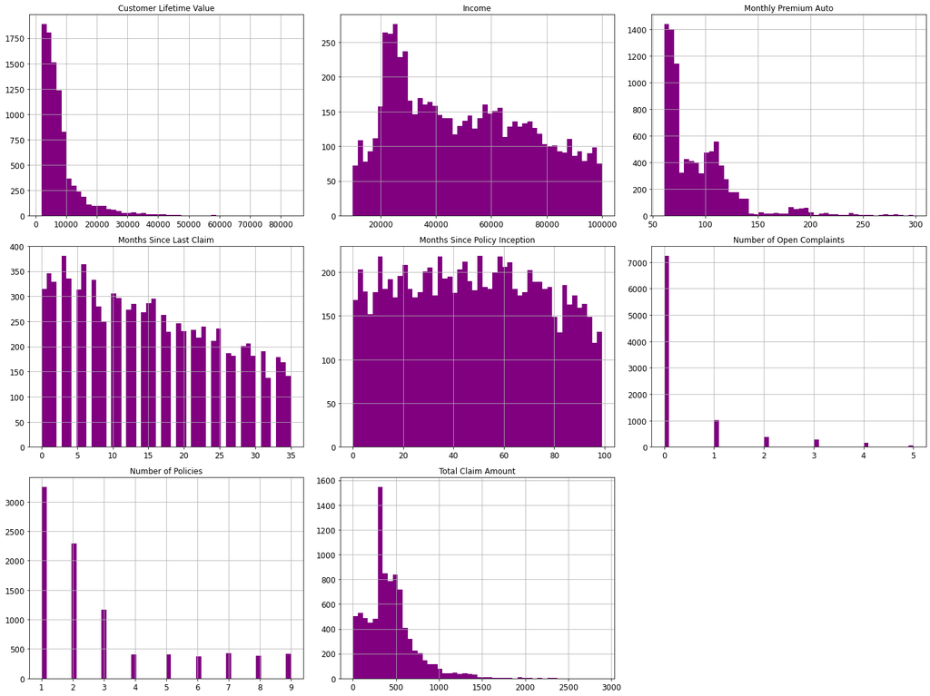

```python
%matplotlib inline
import matplotlib.pyplot as plt
clv.hist(bins=50, figsize=(20,15), color='purple')
save_fig("attribute_histogram_plots")
plt.show()
```

*Note:* *Target variable (CLV) seems heavily right skewed, and has outliers.*

```python
# to make this notebook's output identical at every run
np.random.seed(42)
```

```python
import numpy as np

# For illustration only. Sklearn has train_test_split(). I chose to keep this in my project because it was a good learning exercise.
def split_train_test(data, test_ratio):
    shuffled_indices = np.random.permutation(len(data))
    test_set_size = int(len(data) * test_ratio)
    test_indices = shuffled_indices[:test_set_size]
    train_indices = shuffled_indices[test_set_size:]
    return data.iloc[train_indices], data.iloc[test_indices]
```

```python
train_set, test_set = split_train_test(clv, 0.2)
len(train_set)
```

```
7308
```

```python
len(test_set)
```

```
1826
```

```python
from zlib import crc32

def test_set_check(identifier, test_ratio):
    return crc32(np.int64(identifier)) & 0xffffffff < test_ratio * 2**32

def split_train_test_by_id(data, test_ratio, id_column):
    ids = data[id_column]
    in_test_set = ids.apply(lambda id_: test_set_check(id_, test_ratio))
    return data.loc[~in_test_set], data.loc[in_test_set]
```

*(Kept this into my project for learning purposes):* The implementation of `test_set_check()` above works fine in both Python 2 and Python 3. In earlier releases, the following implementation was proposed, which supported any hash function, but was much slower and did not support Python 2:

```python
import hashlib

def test_set_check(identifier, test_ratio, hash=hashlib.md5):
    return hash(np.int64(identifier)).digest()[-1] < 256 * test_ratio
```

*(Kept this into my project for learning purposes):* If you want an implementation that supports any hash function and is compatible with both Python 2 and Python 3, here is one:

```python
def test_set_check(identifier, test_ratio, hash=hashlib.md5):
    return bytearray(hash(np.int64(identifier)).digest())[-1] < 256 * test_ratio
```

```python
clv_with_id = clv.reset_index()   # adds an `index` column
train_set, test_set = split_train_test_by_id(clv_with_id, 0.2, "index")
```

```python
clv_with_id["id"] = clv["Monthly Premium Auto"] * 1000 + clv["Number of Policies"]
train_set, test_set = split_train_test_by_id(clv_with_id, 0.2, "id")
```

```python
test_set.head()
```

|  | index | State | Customer Lifetime Value | Coverage | Education | EmploymentStatus | Gender | Income | Location Code | Marital Status | ... | Number of Open Complaints | Number of Policies | Policy Type | Policy | Renew Offer Type | Sales Channel | Total Claim Amount | Vehicle Class | Vehicle Size | id |
| --- | --- | --- | --- | --- | --- | --- | --- | --- | --- | --- | --- | --- | --- | --- | --- | --- | --- | --- | --- | --- | --- |
| 5 | 5 | Oregon | 8256.297800 | Basic | Bachelor | Employed | F | 62902.0 | Rural | Married | ... | 0 | 2 | Personal Auto | Personal L3 | Offer2 | Web | 159.383042 | Two-Door Car | Medsize | 69002 |
| 7 | 7 | Arizona | 7216.100311 | Premium | Master | Unemployed | M | NaN | Urban | Single | ... | 0 | 4 | Corporate Auto | Corporate L3 | Offer1 | Agent | 363.029680 | Four-Door Car | Medsize | 101004 |
| 8 | 8 | Oregon | 24127.504020 | Basic | Bachelor | Medical Leave | M | 14072.0 | Suburban | Divorced | ... | 0 | 2 | Corporate Auto | Corporate L3 | Offer1 | Agent | 511.200000 | Four-Door Car | Medsize | 71002 |
| 13 | 13 | Arizona | 8819.018934 | Basic | High School or Below | Employed | M | 99845.0 | Suburban | Married | ... | 1 | 8 | Corporate Auto | Corporate L3 | Offer2 | Branch | 528.000000 | SUV | Medsize | 110008 |
| 19 | 19 | California | 8162.617053 | Premium | High School or Below | Employed | F | 66140.0 | Suburban | Married | ... | 0 | 3 | Corporate Auto | Corporate L2 | Offer1 | Call Center | 484.800000 | Four-Door Car | Small | 101003 |

5 rows × 23 columns

```python
from sklearn.model_selection import train_test_split

train_set, test_set = train_test_split(clv, test_size=0.2, random_state=42)
```

```python
test_set.head()
```

|  | State | Customer Lifetime Value | Coverage | Education | EmploymentStatus | Gender | Income | Location Code | Marital Status | Monthly Premium Auto | ... | Months Since Policy Inception | Number of Open Complaints | Number of Policies | Policy Type | Policy | Renew Offer Type | Sales Channel | Total Claim Amount | Vehicle Class | Vehicle Size |
| --- | --- | --- | --- | --- | --- | --- | --- | --- | --- | --- | --- | --- | --- | --- | --- | --- | --- | --- | --- | --- | --- |
| 708 | California | 4222.631209 | Basic | High School or Below | Employed | M | 74585.0 | Rural | Married | 106 | ... | 49 | 0 | 1 | Personal Auto | Personal L3 | Offer2 | Agent | 218.598065 | SUV | Medsize |
| 47 | Oregon | 5514.344018 | Basic | High School or Below | Employed | F | 23218.0 | Suburban | Single | 71 | ... | 10 | 0 | 4 | Personal Auto | Personal L2 | Offer4 | Agent | 447.793440 | Two-Door Car | Medsize |
| 3995 | Oregon | 3808.122147 | Extended | College | Employed | F | 94903.0 | Suburban | Married | 94 | ... | 38 | 0 | 1 | Personal Auto | Personal L3 | Offer2 | Agent | 451.200000 | Two-Door Car | Small |
| 1513 | California | 7914.823110 | Extended | College | Employed | F | 77153.0 | Urban | Married | 99 | ... | 27 | 1 | 5 | Personal Auto | Personal L3 | Offer1 | Branch | 355.641958 | Four-Door Car | Medsize |
| 3686 | Washington | 7931.722181 | Basic | High School or Below | Disabled | F | 23769.0 | Suburban | Divorced | 69 | ... | 14 | 0 | 2 | Personal Auto | Personal L2 | Offer1 | Branch | 470.097411 | Four-Door Car | Medsize |

5 rows × 21 columns

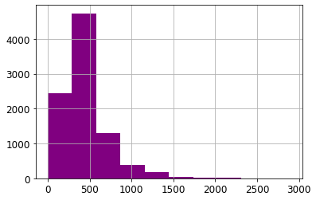

```python
clv["Total Claim Amount"].hist(color='purple')
```

```python
clv["claim_cat"] = pd.cut(clv["Total Claim Amount"],
                               bins=[0., 500, 1000, 1500, 2000, np.inf],
                               labels=[1, 2, 3, 4, 5])
```

```python
clv["claim_cat"].value_counts()
```

```
1    6189
2    2542
3     337
4      47
5      19
Name: claim_cat, dtype: int64
```

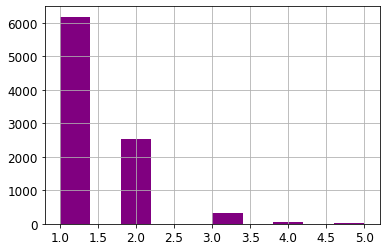

```python
clv["claim_cat"].hist(color='purple')
```

```python
from sklearn.model_selection import StratifiedShuffleSplit

split = StratifiedShuffleSplit(n_splits=1, test_size=0.2, random_state=42)
for train_index, test_index in split.split(clv, clv["claim_cat"]):
    strat_train_set = clv.loc[train_index]
    strat_test_set = clv.loc[test_index]
```

```python
strat_train_set.shape
```

```
(7307, 22)
```

```python
strat_test_set["claim_cat"].value_counts() / len(strat_test_set)
```

```
1    0.677614
2    0.278599
3    0.036672
4    0.004926
5    0.002189
Name: claim_cat, dtype: float64
```

```python
clv["claim_cat"].value_counts() / len(clv)
```

```
1    0.677578
2    0.278301
3    0.036895
4    0.005146
5    0.002080
Name: claim_cat, dtype: float64
```

```python
def claim_cat_proportions(data):
    return data["claim_cat"].value_counts() / len(data)

train_set, test_set = train_test_split(clv, test_size=0.2, random_state=42)

compare_props = pd.DataFrame({
    "Overall": claim_cat_proportions(clv),
    "Stratified": claim_cat_proportions(strat_test_set),
    "Random": claim_cat_proportions(test_set),
}).sort_index()
compare_props["Rand. %error"] = 100 * compare_props["Random"] / compare_props["Overall"] - 100
compare_props["Strat. %error"] = 100 * compare_props["Stratified"] / compare_props["Overall"] - 100
```

```python
compare_props
```

|  | Overall | Stratified | Random | Rand. %error | Strat. %error |
| --- | --- | --- | --- | --- | --- |
| 1 | 0.677578 | 0.677614 | 0.684729 | 1.055344 | 0.005209 |
| 2 | 0.278301 | 0.278599 | 0.280788 | 0.893753 | 0.107057 |
| 3 | 0.036895 | 0.036672 | 0.030104 | -18.406559 | -0.604354 |
| 4 | 0.005146 | 0.004926 | 0.002189 | -57.451467 | -4.265800 |
| 5 | 0.002080 | 0.002189 | 0.002189 | 5.251635 | 5.251635 |

```python
for set_ in (strat_train_set, strat_test_set):
    set_.drop("claim_cat", axis=1, inplace=True)
```

# Discover and visualize the data to gain insights

```python
clv = strat_train_set.copy()
```

```python
clv.shape
```

```
(7307, 21)
```

```python
states = clv[['State','Customer Lifetime Value']]
states1 = states.groupby( [ "State"] ).mean().reset_index()
states1['code']=['AZ','CA','NV','OR','WA']
display(states1)

import plotly.graph_objects as go

fig = go.Figure(data=go.Choropleth(
    locations=states1['code'], # Spatial coordinates
    z = states1['Customer Lifetime Value'].astype(float), # Data to be color-coded
    locationmode = 'USA-states', # set of locations match entries in `locations`
    colorscale = 'Purples',
    #text=states1['Customer Lifetime Value'],
    colorbar_title = "Average CLV (USD)",
))

fig.update_layout(
    title_text = 'Average Customer Lifetime Value by State',
    geo_scope='usa', # limite map scope to USA
)

fig.show();
```

|  | State | Customer Lifetime Value | code |
| --- | --- | --- | --- |
| 0 | Arizona | 7795.684026 | AZ |
| 1 | California | 8101.795274 | CA |
| 2 | Nevada | 8053.615224 | NV |
| 3 | Oregon | 8080.505706 | OR |
| 4 | Washington | 7929.092181 | WA |

[interactive chart not shown]

```python
corr_matrix = clv.corr()
```

```python
corr_matrix["Customer Lifetime Value"].sort_values(ascending=False)
```

```
Customer Lifetime Value          1.000000
Monthly Premium Auto             0.398704
Total Claim Amount               0.228918
Number of Policies               0.021010
Months Since Last Claim          0.010199
Months Since Policy Inception    0.008832
Income                           0.008332
Number of Open Complaints       -0.037097
Name: Customer Lifetime Value, dtype: float64
```

```
Saving figure scatter_matrix_plot
```

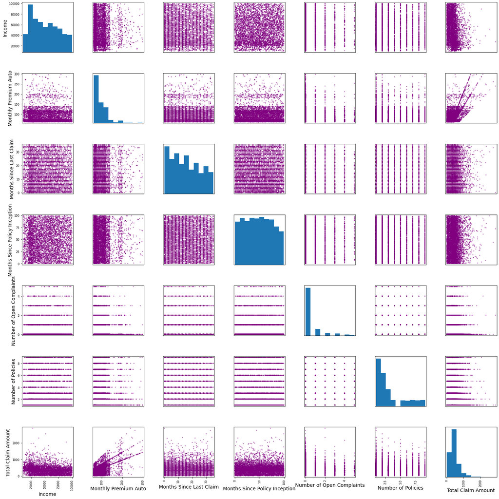

```python
from pandas.plotting import scatter_matrix

attributes = ['Income', 'Monthly Premium Auto', 'Months Since Last Claim',
              'Months Since Policy Inception', 'Number of Open Complaints','Number of Policies','Total Claim Amount']
scatter_matrix(clv[attributes], figsize=(20, 20), color='purple')
save_fig("scatter_matrix_plot")
```

```
Saving figure income_vs_CLV_scatterplot
```

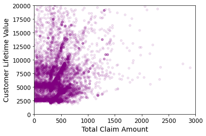

```python
clv.plot(kind="scatter", x="Total Claim Amount", y="Customer Lifetime Value",
             alpha=0.1, color='purple')
plt.axis([0, 3000, 0, 20000])
save_fig("income_vs_CLV_scatterplot")
```

```python
clv["claim_per_policy"] = clv["Total Claim Amount"]/clv["Number of Policies"]
clv["premium_per_policy"] = clv["Monthly Premium Auto"]/clv["Number of Policies"]
clv["complaints_per_months"]=clv["Months Since Policy Inception"]/clv["Number of Open Complaints"]
```

```python
corr_matrix = clv.corr()
corr_matrix["Customer Lifetime Value"].sort_values(ascending=False)
```

```
Customer Lifetime Value          1.000000
Monthly Premium Auto             0.398704
Total Claim Amount               0.228918
complaints_per_months            0.067010
Number of Policies               0.021010
Months Since Last Claim          0.010199
Months Since Policy Inception    0.008832
Income                           0.008332
Number of Open Complaints       -0.037097
claim_per_policy                -0.043332
premium_per_policy              -0.062892
Name: Customer Lifetime Value, dtype: float64
```

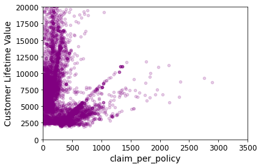

```python
clv.plot(kind="scatter", x="claim_per_policy", y="Customer Lifetime Value",
             alpha=0.2, color='purple')
plt.axis([0, 3500, 0, 20000])
plt.show()
```

```python
clv.describe()
```

|  | Customer Lifetime Value | Income | Monthly Premium Auto | Months Since Last Claim | Months Since Policy Inception | Number of Open Complaints | Number of Policies | Total Claim Amount | claim_per_policy | premium_per_policy | complaints_per_months |
| --- | --- | --- | --- | --- | --- | --- | --- | --- | --- | --- | --- |
| count | 7307.000000 | 5499.000000 | 7307.000000 | 7307.000000 | 7307.000000 | 7307.000000 | 7307.000000 | 7307.000000 | 7307.000000 | 7307.000000 | 7251.0 |
| mean | 8019.267489 | 50481.244044 | 93.237444 | 15.089503 | 47.832900 | 0.384836 | 2.987136 | 434.080999 | 247.389019 | 53.085622 | inf |
| std | 6916.534345 | 24306.440283 | 34.460317 | 10.079437 | 27.888973 | 0.916276 | 2.410818 | 288.201828 | 248.614215 | 40.327359 | NaN |
| min | 1898.007675 | 10037.000000 | 61.000000 | 0.000000 | 0.000000 | 0.000000 | 1.000000 | 0.382107 | 0.141103 | 6.777778 | 0.0 |
| 25% | 3999.497700 | 28330.500000 | 68.000000 | 6.000000 | 24.000000 | 0.000000 | 1.000000 | 272.496757 | 71.180003 | 21.861111 | inf |
| 50% | 5761.317533 | 48117.000000 | 83.000000 | 14.000000 | 48.000000 | 0.000000 | 2.000000 | 384.695536 | 169.600000 | 41.500000 | NaN |
| 75% | 8985.325337 | 70278.000000 | 109.000000 | 23.000000 | 71.000000 | 0.000000 | 4.000000 | 550.056838 | 338.991130 | 71.000000 | inf |
| max | 83325.381190 | 99981.000000 | 298.000000 | 35.000000 | 99.000000 | 5.000000 | 9.000000 | 2893.239678 | 2893.239678 | 298.000000 | inf |

# Prepare the data for Machine Learning algorithms

```python
clv = strat_train_set.drop("Customer Lifetime Value", axis=1) # drop labels for training set
clv_labels = strat_train_set["Customer Lifetime Value"].copy()
```

```python
clv_labels.shape
```

```
(7307,)
```

```python
sample_incomplete_rows = clv[clv.isnull().any(axis=1)].head()
sample_incomplete_rows
```

|  | State | Coverage | Education | EmploymentStatus | Gender | Income | Location Code | Marital Status | Monthly Premium Auto | Months Since Last Claim | Months Since Policy Inception | Number of Open Complaints | Number of Policies | Policy Type | Policy | Renew Offer Type | Sales Channel | Total Claim Amount | Vehicle Class | Vehicle Size |
| --- | --- | --- | --- | --- | --- | --- | --- | --- | --- | --- | --- | --- | --- | --- | --- | --- | --- | --- | --- | --- |
| 3315 | Oregon | Basic | Doctor | Unemployed | F | NaN | Suburban | Single | 73 | 2 | 35 | 0 | 1 | Personal Auto | Personal L2 | Offer1 | Branch | 490.690995 | Four-Door Car | Medsize |
| 6362 | Oregon | Basic | Bachelor | Unemployed | F | NaN | Suburban | Single | 63 | 14 | 45 | 0 | 3 | Personal Auto | Personal L3 | Offer2 | Branch | 419.610914 | Two-Door Car | Medsize |
| 761 | California | Basic | High School or Below | Unemployed | F | NaN | Rural | Married | 104 | 1 | 48 | 3 | 7 | Personal Auto | Personal L3 | Offer1 | Branch | 82.041684 | Sports Car | Medsize |
| 7663 | Oregon | Basic | Bachelor | Unemployed | M | NaN | Suburban | Married | 65 | 32 | 88 | 0 | 1 | Corporate Auto | Corporate L2 | Offer1 | Agent | 312.000000 | Two-Door Car | Medsize |
| 2054 | California | Basic | Bachelor | Unemployed | F | NaN | Suburban | Single | 73 | 35 | 52 | 3 | 5 | Special Auto | Special L3 | Offer1 | Web | 350.400000 | Two-Door Car | Medsize |

*Note:* There are some missing values in the 'Income' variable. Upon closer analysis of the data, these observations correspond to clients who are *Unemployed*, therefore their income is zero. I will therefore fill the missing values with 0.

```python
from sklearn.impute import SimpleImputer
imputer = SimpleImputer(strategy='constant',fill_value= 0)
```

Remove the text attributes

```python
clv_num = clv.select_dtypes(include=[np.number])
```

```python
clv_num
```

|  | Income | Monthly Premium Auto | Months Since Last Claim | Months Since Policy Inception | Number of Open Complaints | Number of Policies | Total Claim Amount |
| --- | --- | --- | --- | --- | --- | --- | --- |
| 3291 | 95647.0 | 106 | 11 | 30 | 0 | 1 | 508.800000 |
| 5780 | 50146.0 | 116 | 6 | 44 | 1 | 1 | 759.291202 |
| 3490 | 77221.0 | 71 | 2 | 49 | 0 | 7 | 259.591385 |
| 6867 | 23931.0 | 95 | 4 | 24 | 0 | 1 | 456.000000 |
| 884 | 72450.0 | 66 | 21 | 58 | 0 | 1 | 84.218363 |
| ... | ... | ... | ... | ... | ... | ... | ... |
| 919 | 21342.0 | 62 | 34 | 72 | 0 | 3 | 74.350893 |
| 214 | 81097.0 | 74 | 7 | 67 | 0 | 1 | 355.200000 |
| 1544 | 61542.0 | 67 | 33 | 83 | 0 | 6 | 321.600000 |
| 1115 | NaN | 69 | 35 | 79 | 0 | 2 | 496.800000 |
| 708 | 74585.0 | 106 | 1 | 49 | 0 | 1 | 218.598065 |

7307 rows × 7 columns

```python
imputer.fit(clv_num)
```

```
SimpleImputer(fill_value=0, strategy='constant')
```

```python
imputer.statistics_
```

```
array([0., 0., 0., 0., 0., 0., 0.])
```

Transform the training set:

```python
X = imputer.transform(clv_num)
```

```python
clv_tr = pd.DataFrame(X, columns=clv_num.columns,
                          index=clv.index)
```

```python
clv_tr.loc[sample_incomplete_rows.index.values]
```

|  | Income | Monthly Premium Auto | Months Since Last Claim | Months Since Policy Inception | Number of Open Complaints | Number of Policies | Total Claim Amount |
| --- | --- | --- | --- | --- | --- | --- | --- |
| 3315 | 0.0 | 73.0 | 2.0 | 35.0 | 0.0 | 1.0 | 490.690995 |
| 6362 | 0.0 | 63.0 | 14.0 | 45.0 | 0.0 | 3.0 | 419.610914 |
| 761 | 0.0 | 104.0 | 1.0 | 48.0 | 3.0 | 7.0 | 82.041684 |
| 7663 | 0.0 | 65.0 | 32.0 | 88.0 | 0.0 | 1.0 | 312.000000 |
| 2054 | 0.0 | 73.0 | 35.0 | 52.0 | 3.0 | 5.0 | 350.400000 |

```python
imputer.strategy
```

```
'constant'
```

```python
clv_tr = pd.DataFrame(X, columns=clv_num.columns,
                          index=clv_num.index)
```

```python
clv_tr.head()
```

|  | Income | Monthly Premium Auto | Months Since Last Claim | Months Since Policy Inception | Number of Open Complaints | Number of Policies | Total Claim Amount |
| --- | --- | --- | --- | --- | --- | --- | --- |
| 3291 | 95647.0 | 106.0 | 11.0 | 30.0 | 0.0 | 1.0 | 508.800000 |
| 5780 | 50146.0 | 116.0 | 6.0 | 44.0 | 1.0 | 1.0 | 759.291202 |
| 3490 | 77221.0 | 71.0 | 2.0 | 49.0 | 0.0 | 7.0 | 259.591385 |
| 6867 | 23931.0 | 95.0 | 4.0 | 24.0 | 0.0 | 1.0 | 456.000000 |
| 884 | 72450.0 | 66.0 | 21.0 | 58.0 | 0.0 | 1.0 | 84.218363 |

Now let's preprocess the categorical input features:

```python
clv_cat = clv.select_dtypes(include=[np.object])
clv_cat.head(10)
```

|  | State | Coverage | Education | EmploymentStatus | Gender | Location Code | Marital Status | Policy Type | Policy | Renew Offer Type | Sales Channel | Vehicle Class | Vehicle Size |
| --- | --- | --- | --- | --- | --- | --- | --- | --- | --- | --- | --- | --- | --- |
| 3291 | Oregon | Premium | Bachelor | Employed | F | Suburban | Single | Personal Auto | Personal L2 | Offer1 | Agent | Two-Door Car | Medsize |
| 5780 | California | Basic | Bachelor | Employed | M | Suburban | Married | Personal Auto | Personal L3 | Offer2 | Branch | SUV | Medsize |
| 3490 | Oregon | Basic | Doctor | Employed | F | Urban | Married | Personal Auto | Personal L3 | Offer2 | Call Center | Four-Door Car | Medsize |
| 6867 | Oregon | Extended | College | Retired | F | Suburban | Single | Personal Auto | Personal L3 | Offer4 | Web | Four-Door Car | Large |
| 884 | Washington | Basic | Doctor | Employed | F | Rural | Married | Corporate Auto | Corporate L3 | Offer4 | Branch | Four-Door Car | Medsize |
| 1691 | California | Basic | Bachelor | Employed | F | Suburban | Married | Corporate Auto | Corporate L1 | Offer4 | Call Center | Four-Door Car | Medsize |
| 3047 | Arizona | Basic | Master | Employed | F | Urban | Married | Personal Auto | Personal L1 | Offer2 | Call Center | Four-Door Car | Medsize |
| 1480 | Oregon | Basic | Bachelor | Employed | F | Urban | Divorced | Corporate Auto | Corporate L3 | Offer2 | Call Center | Four-Door Car | Medsize |
| 8772 | California | Extended | High School or Below | Employed | F | Suburban | Married | Personal Auto | Personal L3 | Offer4 | Agent | Two-Door Car | Medsize |
| 3315 | Oregon | Basic | Doctor | Unemployed | F | Suburban | Single | Personal Auto | Personal L2 | Offer1 | Branch | Four-Door Car | Medsize |

*Ordinal Encoder* is not necessary for my dataset as my categories do not need to be ordered. But once again...learning opportunity! :)

```python
from sklearn.preprocessing import OrdinalEncoder

ordinal_encoder = OrdinalEncoder()
clv_cat_encoded = ordinal_encoder.fit_transform(clv_cat)
clv_cat_encoded[:10]
```

```
array([[3., 2., 0., 1., 0., 1., 2., 1., 4., 0., 0., 5., 1.],
       [1., 0., 0., 1., 1., 1., 1., 1., 5., 1., 1., 3., 1.],
       [3., 0., 2., 1., 0., 2., 1., 1., 5., 1., 2., 0., 1.],
       [3., 1., 1., 3., 0., 1., 2., 1., 5., 3., 3., 0., 0.],
       [4., 0., 2., 1., 0., 0., 1., 0., 2., 3., 1., 0., 1.],
       [1., 0., 0., 1., 0., 1., 1., 0., 0., 3., 2., 0., 1.],
       [0., 0., 4., 1., 0., 2., 1., 1., 3., 1., 2., 0., 1.],
       [3., 0., 0., 1., 0., 2., 0., 0., 2., 1., 2., 0., 1.],
       [1., 1., 3., 1., 0., 1., 1., 1., 5., 3., 0., 5., 1.],
       [3., 0., 2., 4., 0., 1., 2., 1., 4., 0., 1., 0., 1.]])
```

```python
ordinal_encoder.categories_
```

```
[array(['Arizona', 'California', 'Nevada', 'Oregon', 'Washington'],
       dtype=object),
 array(['Basic', 'Extended', 'Premium'], dtype=object),
 array(['Bachelor', 'College', 'Doctor', 'High School or Below', 'Master'],
       dtype=object),
 array(['Disabled', 'Employed', 'Medical Leave', 'Retired', 'Unemployed'],
       dtype=object),
 array(['F', 'M'], dtype=object),
 array(['Rural', 'Suburban', 'Urban'], dtype=object),
 array(['Divorced', 'Married', 'Single'], dtype=object),
 array(['Corporate Auto', 'Personal Auto', 'Special Auto'], dtype=object),
 array(['Corporate L1', 'Corporate L2', 'Corporate L3', 'Personal L1',
        'Personal L2', 'Personal L3', 'Special L1', 'Special L2',
        'Special L3'], dtype=object),
 array(['Offer1', 'Offer2', 'Offer3', 'Offer4'], dtype=object),
 array(['Agent', 'Branch', 'Call Center', 'Web'], dtype=object),
 array(['Four-Door Car', 'Luxury Car', 'Luxury SUV', 'SUV', 'Sports Car',
        'Two-Door Car'], dtype=object),
 array(['Large', 'Medsize', 'Small'], dtype=object)]
```

```python
from sklearn.preprocessing import OneHotEncoder

cat_encoder = OneHotEncoder()
clv_cat_1hot = cat_encoder.fit_transform(clv_cat)
clv_cat_1hot
```

```
<7307x55 sparse matrix of type '<class 'numpy.float64'>'
	with 94991 stored elements in Compressed Sparse Row format>
```

By default, the `OneHotEncoder` class returns a sparse array, but we can convert it to a dense array if needed by calling the `toarray()` method:

```python
clv_cat_1hot.toarray()
```

```
array([[0., 0., 0., ..., 0., 1., 0.],
       [0., 1., 0., ..., 0., 1., 0.],
       [0., 0., 0., ..., 0., 1., 0.],
       ...,
       [0., 1., 0., ..., 0., 1., 0.],
       [0., 0., 0., ..., 0., 1., 0.],
       [0., 1., 0., ..., 0., 1., 0.]])
```

Alternatively, you can set `sparse=False` when creating the `OneHotEncoder`:

```python
cat_encoder = OneHotEncoder(sparse=False)
clv_cat_1hot = cat_encoder.fit_transform(clv_cat)
clv_cat_1hot
```

```
array([[0., 0., 0., ..., 0., 1., 0.],
       [0., 1., 0., ..., 0., 1., 0.],
       [0., 0., 0., ..., 0., 1., 0.],
       ...,
       [0., 1., 0., ..., 0., 1., 0.],
       [0., 0., 0., ..., 0., 1., 0.],
       [0., 1., 0., ..., 0., 1., 0.]])
```

```python
cat_encoder.categories_
```

```
[array(['Arizona', 'California', 'Nevada', 'Oregon', 'Washington'],
       dtype=object),
 array(['Basic', 'Extended', 'Premium'], dtype=object),
 array(['Bachelor', 'College', 'Doctor', 'High School or Below', 'Master'],
       dtype=object),
 array(['Disabled', 'Employed', 'Medical Leave', 'Retired', 'Unemployed'],
       dtype=object),
 array(['F', 'M'], dtype=object),
 array(['Rural', 'Suburban', 'Urban'], dtype=object),
 array(['Divorced', 'Married', 'Single'], dtype=object),
 array(['Corporate Auto', 'Personal Auto', 'Special Auto'], dtype=object),
 array(['Corporate L1', 'Corporate L2', 'Corporate L3', 'Personal L1',
        'Personal L2', 'Personal L3', 'Special L1', 'Special L2',
        'Special L3'], dtype=object),
 array(['Offer1', 'Offer2', 'Offer3', 'Offer4'], dtype=object),
 array(['Agent', 'Branch', 'Call Center', 'Web'], dtype=object),
 array(['Four-Door Car', 'Luxury Car', 'Luxury SUV', 'SUV', 'Sports Car',
        'Two-Door Car'], dtype=object),
 array(['Large', 'Medsize', 'Small'], dtype=object)]
```

Let's create a custom transformer to add extra attributes:

```python
from sklearn.base import BaseEstimator, TransformerMixin

# column index
col_names = "Total Claim Amount", "Number of Policies", "Number of Open Complaints",
claims_ix, policy_ix, complaints_ix = [
    clv.columns.get_loc(c) for c in col_names] # get the column indices

class CombinedAttributesAdder(BaseEstimator, TransformerMixin):
    def __init__(self, add_claims_per_policy=True): # no *args or **kargs
        self.add_claims_per_policy = add_claims_per_policy
    def fit(self, X, y=None):
        return self  # nothing else to do
    def transform(self, X):
        premium_per_policy = X[:, premium_ix] / X[:, policy_ix]
        complaints_per_policy = X[:, complaints_ix] / X[:, policy_ix]
        if self.add_claims_per_policy:
            claims_per_policy = X[:, claims_ix] / X[:, policy_ix]
            return np.c_[X, premium_per_policy, complaints_per_policy,
                         claims_per_policy]
        else:
            return np.c_[X, premium_per_policy, complaints_per_policy]

attr_adder = CombinedAttributesAdder(add_claims_per_policy=False)
clv_extra_attribs = attr_adder.transform(clv.values)
```

Also, `clv_extra_attribs` is a NumPy array, we've lost the column names. To recover a `DataFrame`, you could run this:

```python
clv_extra_attribs = pd.DataFrame(
    clv_extra_attribs,
    columns=list(clv.columns)+["premium_per_policy", "complaints_per_policy"],
    index=clv.index)
clv_extra_attribs.head()
```

|  | State | Coverage | Education | EmploymentStatus | Gender | Income | Location Code | Marital Status | Monthly Premium Auto | Months Since Last Claim | ... | Number of Policies | Policy Type | Policy | Renew Offer Type | Sales Channel | Total Claim Amount | Vehicle Class | Vehicle Size | premium_per_policy | complaints_per_policy |
| --- | --- | --- | --- | --- | --- | --- | --- | --- | --- | --- | --- | --- | --- | --- | --- | --- | --- | --- | --- | --- | --- |
| 3291 | Oregon | Premium | Bachelor | Employed | F | 95647 | Suburban | Single | 106 | 11 | ... | 1 | Personal Auto | Personal L2 | Offer1 | Agent | 508.8 | Two-Door Car | Medsize | 106 | 0 |
| 5780 | California | Basic | Bachelor | Employed | M | 50146 | Suburban | Married | 116 | 6 | ... | 1 | Personal Auto | Personal L3 | Offer2 | Branch | 759.291 | SUV | Medsize | 116 | 1 |
| 3490 | Oregon | Basic | Doctor | Employed | F | 77221 | Urban | Married | 71 | 2 | ... | 7 | Personal Auto | Personal L3 | Offer2 | Call Center | 259.591 | Four-Door Car | Medsize | 10.1429 | 0 |
| 6867 | Oregon | Extended | College | Retired | F | 23931 | Suburban | Single | 95 | 4 | ... | 1 | Personal Auto | Personal L3 | Offer4 | Web | 456 | Four-Door Car | Large | 95 | 0 |
| 884 | Washington | Basic | Doctor | Employed | F | 72450 | Rural | Married | 66 | 21 | ... | 1 | Corporate Auto | Corporate L3 | Offer4 | Branch | 84.2184 | Four-Door Car | Medsize | 66 | 0 |

5 rows × 22 columns

Now let's build a pipeline for preprocessing the numerical attributes:

```python
clv_num.shape
```

```
(7307, 7)
```

```python
from sklearn.pipeline import Pipeline
from sklearn.preprocessing import StandardScaler

num_pipeline = Pipeline([
        ('imputer', SimpleImputer(strategy='constant',fill_value= 0)),
        #('attribs_adder', CombinedAttributesAdder()), Extra attributes are not needed
        ('std_scaler', StandardScaler()),
    ])

clv_num_tr = num_pipeline.fit_transform(clv_num)
```

```python
clv_num_tr
```

```
array([[ 1.90184326,  0.37038052, -0.4057551 , ..., -0.42002926,
        -0.82431423,  0.25927703],
       [ 0.40095915,  0.66058924, -0.90184849, ...,  0.67141946,
        -0.82431423,  1.12848853],
       [ 1.29404803, -0.64535   , -1.29872321, ..., -0.42002926,
         1.66463786, -0.60548386],
       ...,
       [ 0.77686463, -0.76143349,  1.77705582, ..., -0.42002926,
         1.24981252, -0.39031223],
       [-1.25314371, -0.70339175,  1.97549317, ..., -0.42002926,
        -0.40948888,  0.21763669],
       [ 1.20709763,  0.37038052, -1.39794189, ..., -0.42002926,
        -0.82431423, -0.74773183]])
```

```python
from sklearn.compose import ColumnTransformer

num_attribs = list(clv_num)
cat_attribs = list(clv_cat)

full_pipeline = ColumnTransformer([
        ("num", num_pipeline, num_attribs),
        ("cat", OneHotEncoder(), cat_attribs),
    ])

clv_prepared = full_pipeline.fit_transform(clv)
```

```python
clv_prepared
```

```
array([[ 1.90184326,  0.37038052, -0.4057551 , ...,  0.        ,
         1.        ,  0.        ],
       [ 0.40095915,  0.66058924, -0.90184849, ...,  0.        ,
         1.        ,  0.        ],
       [ 1.29404803, -0.64535   , -1.29872321, ...,  0.        ,
         1.        ,  0.        ],
       ...,
       [ 0.77686463, -0.76143349,  1.77705582, ...,  0.        ,
         1.        ,  0.        ],
       [-1.25314371, -0.70339175,  1.97549317, ...,  0.        ,
         1.        ,  0.        ],
       [ 1.20709763,  0.37038052, -1.39794189, ...,  0.        ,
         1.        ,  0.        ]])
```

```python
clv_prepared.shape
```

```
(7307, 62)
```

*(Kept in the project for learning purposes):* For reference, here is the old solution based on a `DataFrameSelector` transformer (to just select a subset of the Pandas `DataFrame` columns), and a `FeatureUnion`:

```python
from sklearn.base import BaseEstimator, TransformerMixin

class OldDataFrameSelector(BaseEstimator, TransformerMixin):
    def __init__(self, attribute_names):
        self.attribute_names = attribute_names
    def fit(self, X, y=None):
        return self
    def transform(self, X):
        return X[self.attribute_names].values
```

Now let's join all these components into a big pipeline that will preprocess both the numerical and the categorical features:

```python
num_attribs = list(clv_num)
cat_attribs = list(clv_cat)

old_num_pipeline = Pipeline([
        ('selector', OldDataFrameSelector(num_attribs)),
        ('imputer', SimpleImputer(strategy='constant',fill_value= 0)),
        ('std_scaler', StandardScaler()),
    ])

old_cat_pipeline = Pipeline([
        ('selector', OldDataFrameSelector(cat_attribs)),
        ('cat_encoder', OneHotEncoder(sparse=False)),
    ])
```

```python
from sklearn.pipeline import FeatureUnion

old_full_pipeline = FeatureUnion(transformer_list=[
        ("num_pipeline", old_num_pipeline),
        ("cat_pipeline", old_cat_pipeline),
    ])
```

```python
old_clv_prepared = old_full_pipeline.fit_transform(clv)
old_clv_prepared
```

```
array([[ 1.90184326,  0.37038052, -0.4057551 , ...,  0.        ,
         1.        ,  0.        ],
       [ 0.40095915,  0.66058924, -0.90184849, ...,  0.        ,
         1.        ,  0.        ],
       [ 1.29404803, -0.64535   , -1.29872321, ...,  0.        ,
         1.        ,  0.        ],
       ...,
       [ 0.77686463, -0.76143349,  1.77705582, ...,  0.        ,
         1.        ,  0.        ],
       [-1.25314371, -0.70339175,  1.97549317, ...,  0.        ,
         1.        ,  0.        ],
       [ 1.20709763,  0.37038052, -1.39794189, ...,  0.        ,
         1.        ,  0.        ]])
```

The result is the same as with the `ColumnTransformer`:

```python
np.allclose(clv_prepared, old_clv_prepared)
```

```
True
```

# Select and train a model

```python
from sklearn.linear_model import LinearRegression

lin_reg = LinearRegression()
lin_reg.fit(clv_prepared, clv_labels)
```

```
LinearRegression()
```

```python
# let's try the full preprocessing pipeline on a few training instances
some_data = clv.iloc[:5]
some_labels = clv_labels.iloc[:5]
some_data_prepared = full_pipeline.transform(some_data)

print("Predictions:", lin_reg.predict(some_data_prepared))
```

```
Predictions: [8913.  9466.  6308.5 6043.5 5618. ]
```

Compare against the actual values:

```python
print("Labels:", list(some_labels))
```

```
Labels: [4233.56878, 4514.247472999999, 5789.8509, 3304.758268, 2678.058299]
```

```python
some_data_prepared
```

```
array([[ 1.90184326,  0.37038052, -0.4057551 , -0.63946852, -0.42002926,
        -0.82431423,  0.25927703,  0.        ,  0.        ,  0.        ,
         1.        ,  0.        ,  0.        ,  0.        ,  1.        ,
         1.        ,  0.        ,  0.        ,  0.        ,  0.        ,
         0.        ,  1.        ,  0.        ,  0.        ,  0.        ,
         1.        ,  0.        ,  0.        ,  1.        ,  0.        ,
         0.        ,  0.        ,  1.        ,  0.        ,  1.        ,
         0.        ,  0.        ,  0.        ,  0.        ,  0.        ,
         1.        ,  0.        ,  0.        ,  0.        ,  0.        ,
         1.        ,  0.        ,  0.        ,  0.        ,  1.        ,
         0.        ,  0.        ,  0.        ,  0.        ,  0.        ,
         0.        ,  0.        ,  0.        ,  1.        ,  0.        ,
         1.        ,  0.        ],
       [ 0.40095915,  0.66058924, -0.90184849, -0.13744365,  0.67141946,
        -0.82431423,  1.12848853,  0.        ,  1.        ,  0.        ,
         0.        ,  0.        ,  1.        ,  0.        ,  0.        ,
         1.        ,  0.        ,  0.        ,  0.        ,  0.        ,
         0.        ,  1.        ,  0.        ,  0.        ,  0.        ,
         0.        ,  1.        ,  0.        ,  1.        ,  0.        ,
         0.        ,  1.        ,  0.        ,  0.        ,  1.        ,
         0.        ,  0.        ,  0.        ,  0.        ,  0.        ,
         0.        ,  1.        ,  0.        ,  0.        ,  0.        ,
         0.        ,  1.        ,  0.        ,  0.        ,  0.        ,
         1.        ,  0.        ,  0.        ,  0.        ,  0.        ,
         0.        ,  1.        ,  0.        ,  0.        ,  0.        ,
         1.        ,  0.        ],
       [ 1.29404803, -0.64535   , -1.29872321,  0.04185095, -0.42002926,
         1.66463786, -0.60548386,  0.        ,  0.        ,  0.        ,
         1.        ,  0.        ,  1.        ,  0.        ,  0.        ,
         0.        ,  0.        ,  1.        ,  0.        ,  0.        ,
         0.        ,  1.        ,  0.        ,  0.        ,  0.        ,
         1.        ,  0.        ,  0.        ,  0.        ,  1.        ,
         0.        ,  1.        ,  0.        ,  0.        ,  1.        ,
         0.        ,  0.        ,  0.        ,  0.        ,  0.        ,
         0.        ,  1.        ,  0.        ,  0.        ,  0.        ,
         0.        ,  1.        ,  0.        ,  0.        ,  0.        ,
         0.        ,  1.        ,  0.        ,  1.        ,  0.        ,
         0.        ,  0.        ,  0.        ,  0.        ,  0.        ,
         1.        ,  0.        ],
       [-0.46376199,  0.05115093, -1.10028585, -0.85462203, -0.42002926,
```

[output cut: 10 more lines]

```
         0.        ,  0.        ,  0.        ,  0.        ,  1.        ,
         0.        ,  0.        ],
       [ 1.13667307, -0.79045436,  0.58643168,  0.36458122, -0.42002926,
        -0.82431423, -1.21403317,  0.        ,  0.        ,  0.        ,
         0.        ,  1.        ,  1.        ,  0.        ,  0.        ,
         0.        ,  0.        ,  1.        ,  0.        ,  0.        ,
         0.        ,  1.        ,  0.        ,  0.        ,  0.        ,
         1.        ,  0.        ,  1.        ,  0.        ,  0.        ,
         0.        ,  1.        ,  0.        ,  1.        ,  0.        ,
         0.        ,  0.        ,  0.        ,  1.        ,  0.        ,
         0.        ,  0.        ,  0.        ,  0.        ,  0.        ,
         0.        ,  0.        ,  0.        ,  1.        ,  0.        ,
         1.        ,  0.        ,  0.        ,  1.        ,  0.        ,
         0.        ,  0.        ,  0.        ,  0.        ,  0.        ,
         1.        ,  0.        ]])
```

```python
from sklearn.metrics import mean_squared_error

clv_predictions = lin_reg.predict(clv_prepared)
lin_mse = mean_squared_error(clv_labels, clv_predictions)
lin_rmse = np.sqrt(lin_mse)
lin_rmse
```

```
6294.142993034274
```

```python
from sklearn.metrics import mean_absolute_error

lin_mae = mean_absolute_error(clv_labels, clv_predictions)
lin_mae
```

```
3890.3913345184073
```

```python
from sklearn.tree import DecisionTreeRegressor

tree_reg = DecisionTreeRegressor(random_state=42)
tree_reg.fit(clv_prepared, clv_labels)
```

```
DecisionTreeRegressor(random_state=42)
```

```python
clv_predictions = tree_reg.predict(clv_prepared)
tree_mse = mean_squared_error(clv_labels, clv_predictions)
tree_rmse = np.sqrt(tree_mse)
tree_rmse
```

```
1.595959546227909e-13
```

# Fine-tune your model

```python
from sklearn.model_selection import cross_val_score

scores = cross_val_score(tree_reg, clv_prepared, clv_labels,
                         scoring="neg_mean_squared_error", cv=10)
tree_rmse_scores = np.sqrt(-scores)
```

```python
def display_scores(scores):
    print("Scores:", scores)
    print("Mean:", scores.mean())
    print("Standard deviation:", scores.std())

display_scores(tree_rmse_scores)
```

```
Scores: [4822.72002071 5664.34022476 5987.82297585 4898.59950092 4738.91948622
 5483.7119107  5232.38755835 5744.74725197 4876.5411286  5042.67750379]
Mean: 5249.246756186329
Standard deviation: 420.1748587803932
```

```python
lin_scores = cross_val_score(lin_reg, clv_prepared, clv_labels,
                             scoring="neg_mean_squared_error", cv=10)
lin_rmse_scores = np.sqrt(-lin_scores)
display_scores(lin_rmse_scores)
```

```
Scores: [6024.9857029  6215.56831008 6398.81245273 6072.47349529 6406.39826792
 6874.06762194 6253.1223379  6340.22873446 6399.29135198 6427.61437608]
Mean: 6341.256265127852
Standard deviation: 223.18317246896598
```

**Note**: we specify `n_estimators=100`

```python
from sklearn.ensemble import RandomForestRegressor

forest_reg = RandomForestRegressor(n_estimators=100, random_state=42)
forest_reg.fit(clv_prepared, clv_labels)
```

```
RandomForestRegressor(random_state=42)
```

```python
clv_predictions = forest_reg.predict(clv_prepared)
forest_mse = mean_squared_error(clv_labels, clv_predictions)
forest_rmse = np.sqrt(forest_mse)
forest_rmse
```

```
1411.3072286906904
```

```python
from sklearn.model_selection import cross_val_score

forest_scores = cross_val_score(forest_reg, clv_prepared, clv_labels,
                                scoring="neg_mean_squared_error", cv=10)
forest_rmse_scores = np.sqrt(-forest_scores)
display_scores(forest_rmse_scores)
```

```
Scores: [3521.73954972 3844.61385277 4153.04437453 3321.60087911 3424.95944562
 3766.10790323 3965.376792   3864.80946009 3616.91912857 3872.64911834]
Mean: 3735.182050398823
Standard deviation: 245.57320667802637
```

```python
scores = cross_val_score(lin_reg, clv_prepared, clv_labels, scoring="neg_mean_squared_error", cv=10)
pd.Series(np.sqrt(-scores)).describe()
```

```
count      10.000000
mean     6341.256265
std       235.255720
min      6024.985703
25%      6224.956817
50%      6369.520594
75%      6404.621539
max      6874.067622
dtype: float64
```

```python
from sklearn.svm import SVR

svm_reg = SVR(kernel="linear")
svm_reg.fit(clv_prepared, clv_labels)
clv_predictions = svm_reg.predict(clv_prepared)
svm_mse = mean_squared_error(clv_labels, clv_predictions)
svm_rmse = np.sqrt(svm_mse)
svm_rmse
```

```
6857.440240790027
```

```python
#This is what came with the template, but I do not think that the numbers match my dataset,
#so I used the GridSearch in the cell below with different values for the hyperparameters

""""
from sklearn.model_selection import GridSearchCV

param_grid = [
    # try 12 (3×4) combinations of hyperparameters
    {'n_estimators': [3, 10, 30], 'max_features': [2, 4, 6, 8]},
    # then try 6 (2×3) combinations with bootstrap set as False
    {'bootstrap': [False], 'n_estimators': [3, 10], 'max_features': [2, 3, 4]},
  ]

forest_reg = RandomForestRegressor(random_state=42)
 #train across 5 folds, that's a total of (12+6)*5=90 rounds of training
grid_search = GridSearchCV(forest_reg, param_grid, cv=5,
                           scoring='neg_mean_squared_error',
                           return_train_score=True, n_jobs=-1)
grid_search.fit(clv_prepared, clv_labels)
```

```python
## I attempted to vary the hyperparameters based on my dataset. When I used the same code as the template (see cell above),
#the best parameterss came out to be: max_features=8 and n_estimators=100, so I kept those in as well to see if they would
#still come out as the best parameters.


from sklearn.model_selection import GridSearchCV

param_grid = [
    # try 12 (3×4) combinations of hyperparameters
    {'n_estimators': [10, 30, 50, 100], 'max_features': [8,20, 40, 60]},
    # then try 6 (2×3) combinations with bootstrap set as False
    {'bootstrap': [False], 'n_estimators': [50, 100], 'max_features': [8, 40, 60]},
  ]

forest_reg = RandomForestRegressor(random_state=42)
# train across 5 folds, that's a total of (12+6)*5=90 rounds of training
grid_search = GridSearchCV(forest_reg, param_grid, cv=5,
                           scoring='neg_mean_squared_error',
                           return_train_score=True, n_jobs=-1)
grid_search.fit(clv_prepared, clv_labels)
```

```
GridSearchCV(cv=5, estimator=RandomForestRegressor(random_state=42), n_jobs=-1,
             param_grid=[{'max_features': [8, 20, 40, 60],
                          'n_estimators': [10, 30, 50, 100]},
                         {'bootstrap': [False], 'max_features': [8, 40, 60],
                          'n_estimators': [50, 100]}],
             return_train_score=True, scoring='neg_mean_squared_error')
```

The best hyperparameter combination found:

```python
grid_search.best_params_
```

```
{'max_features': 40, 'n_estimators': 100}
```

```python
clv_prepared.shape
```

```
(7307, 62)
```

```python
grid_search.best_estimator_
```

```
RandomForestRegressor(max_features=40, random_state=42)
```

Let's look at the score of each hyperparameter combination tested during the grid search:

```python
cvres = grid_search.cv_results_
for mean_score, params in zip(cvres["mean_test_score"], cvres["params"]):
    print(np.sqrt(-mean_score), params)
```

```
4403.365701064269 {'max_features': 8, 'n_estimators': 10}
4290.013866841781 {'max_features': 8, 'n_estimators': 30}
4268.567847944143 {'max_features': 8, 'n_estimators': 50}
4244.216429903887 {'max_features': 8, 'n_estimators': 100}
3988.979445046827 {'max_features': 20, 'n_estimators': 10}
3791.1837099385757 {'max_features': 20, 'n_estimators': 30}
3743.630919154946 {'max_features': 20, 'n_estimators': 50}
3728.6267185978786 {'max_features': 20, 'n_estimators': 100}
3879.383171081797 {'max_features': 40, 'n_estimators': 10}
3750.456318083833 {'max_features': 40, 'n_estimators': 30}
3720.475836057723 {'max_features': 40, 'n_estimators': 50}
3712.024759774453 {'max_features': 40, 'n_estimators': 100}
3946.007624571434 {'max_features': 60, 'n_estimators': 10}
3794.908066403392 {'max_features': 60, 'n_estimators': 30}
3767.742347867651 {'max_features': 60, 'n_estimators': 50}
3758.2945327370467 {'max_features': 60, 'n_estimators': 100}
4183.537551585236 {'bootstrap': False, 'max_features': 8, 'n_estimators': 50}
4153.708869227751 {'bootstrap': False, 'max_features': 8, 'n_estimators': 100}
3925.0940944312038 {'bootstrap': False, 'max_features': 40, 'n_estimators': 50}
3882.7226587151463 {'bootstrap': False, 'max_features': 40, 'n_estimators': 100}
4790.221916937768 {'bootstrap': False, 'max_features': 60, 'n_estimators': 50}
4788.739864064859 {'bootstrap': False, 'max_features': 60, 'n_estimators': 100}
```

```python
pd.DataFrame(grid_search.cv_results_)
```

|  | mean_fit_time | std_fit_time | mean_score_time | std_score_time | param_max_features | param_n_estimators | param_bootstrap | params | split0_test_score | split1_test_score | ... | mean_test_score | std_test_score | rank_test_score | split0_train_score | split1_train_score | split2_train_score | split3_train_score | split4_train_score | mean_train_score | std_train_score |
| --- | --- | --- | --- | --- | --- | --- | --- | --- | --- | --- | --- | --- | --- | --- | --- | --- | --- | --- | --- | --- | --- |
| 0 | 0.399312 | 0.007889 | 0.017200 | 0.003599 | 8 | 10 | NaN | {'max_features': 8, 'n_estimators': 10} | -1.749195e+07 | -1.857740e+07 | ... | -1.938963e+07 | 1.429801e+06 | 20 | -3.494476e+06 | -3.809300e+06 | -3.551063e+06 | -3.863159e+06 | -3.867560e+06 | -3.717112e+06 | 1.609980e+05 |
| 1 | 1.202215 | 0.076503 | 0.035402 | 0.004128 | 8 | 30 | NaN | {'max_features': 8, 'n_estimators': 30} | -1.770285e+07 | -1.801573e+07 | ... | -1.840422e+07 | 9.688002e+05 | 19 | -2.820588e+06 | -2.829103e+06 | -2.848274e+06 | -2.999129e+06 | -2.943124e+06 | -2.888044e+06 | 7.068199e+04 |
| 2 | 2.327108 | 0.227928 | 0.068401 | 0.009953 | 8 | 50 | NaN | {'max_features': 8, 'n_estimators': 50} | -1.727516e+07 | -1.826145e+07 | ... | -1.822067e+07 | 9.203897e+05 | 18 | -2.657186e+06 | -2.684021e+06 | -2.616771e+06 | -2.843075e+06 | -2.745029e+06 | -2.709216e+06 | 7.885270e+04 |
| 3 | 4.817346 | 0.662453 | 0.132908 | 0.021909 | 8 | 100 | NaN | {'max_features': 8, 'n_estimators': 100} | -1.691992e+07 | -1.838467e+07 | ... | -1.801337e+07 | 9.439482e+05 | 17 | -2.592579e+06 | -2.518783e+06 | -2.497691e+06 | -2.598622e+06 | -2.513331e+06 | -2.544201e+06 | 4.257783e+04 |
| 4 | 0.890830 | 0.166427 | 0.014001 | 0.002280 | 20 | 10 | NaN | {'max_features': 20, 'n_estimators': 10} | -1.574527e+07 | -1.591027e+07 | ... | -1.591196e+07 | 4.335137e+05 | 14 | -3.112757e+06 | -3.265083e+06 | -2.824273e+06 | -2.678473e+06 | -2.689579e+06 | -2.914033e+06 | 2.352242e+05 |
| 5 | 2.450396 | 0.352173 | 0.043799 | 0.005345 | 20 | 30 | NaN | {'max_features': 20, 'n_estimators': 30} | -1.373282e+07 | -1.451310e+07 | ... | -1.437307e+07 | 5.177370e+05 | 8 | -2.248008e+06 | -2.266430e+06 | -2.185419e+06 | -2.199744e+06 | -2.223281e+06 | -2.224576e+06 | 2.984084e+04 |
| 6 | 4.186313 | 0.387331 | 0.078402 | 0.034187 | 20 | 50 | NaN | {'max_features': 20, 'n_estimators': 50} | -1.344946e+07 | -1.437799e+07 | ... | -1.401477e+07 | 4.251027e+05 | 4 | -2.096435e+06 | -2.095763e+06 | -2.026113e+06 | -2.014350e+06 | -2.067571e+06 | -2.060046e+06 | 3.433964e+04 |
| 7 | 8.297374 | 0.437267 | 0.153606 | 0.059094 | 20 | 100 | NaN | {'max_features': 20, 'n_estimators': 100} | -1.327060e+07 | -1.453291e+07 | ... | -1.390266e+07 | 4.882021e+05 | 3 | -2.014658e+06 | -1.967179e+06 | -1.948558e+06 | -1.937457e+06 | -1.953941e+06 | -1.964359e+06 | 2.690683e+04 |
| 8 | 1.475109 | 0.086603 | 0.028204 | 0.006736 | 40 | 10 | NaN | {'max_features': 40, 'n_estimators': 10} | -1.464586e+07 | -1.526393e+07 | ... | -1.504961e+07 | 7.709178e+05 | 10 | -3.091331e+06 | -3.000977e+06 | -2.781077e+06 | -2.690736e+06 | -2.626206e+06 | -2.838066e+06 | 1.791769e+05 |
| 9 | 4.630572 | 0.239464 | 0.035401 | 0.007446 | 40 | 30 | NaN | {'max_features': 40, 'n_estimators': 30} | -1.388356e+07 | -1.404325e+07 | ... | -1.406592e+07 | 1.805252e+05 | 5 | -2.224051e+06 | -2.186926e+06 | -2.209669e+06 | -2.124355e+06 | -2.159195e+06 | -2.180839e+06 | 3.576149e+04 |
| 10 | 6.305794 | 0.716458 | 0.078406 | 0.011484 | 40 | 50 | NaN | {'max_features': 40, 'n_estimators': 50} | -1.341836e+07 | -1.394093e+07 | ... | -1.384194e+07 | 2.345998e+05 | 2 | -2.086106e+06 | -2.057343e+06 | -2.032963e+06 | -1.963654e+06 | -2.043677e+06 | -2.036748e+06 | 4.065818e+04 |
| 11 | 13.135452 | 0.887026 | 0.161804 | 0.032678 | 40 | 100 | NaN | {'max_features': 40, 'n_estimators': 100} | -1.323796e+07 | -1.410974e+07 | ... | -1.377913e+07 | 4.630464e+05 | 1 | -1.968550e+06 | -1.904870e+06 | -2.011196e+06 | -1.917021e+06 | -1.946680e+06 | -1.949663e+06 | 3.800982e+04 |
| 12 | 1.740432 | 0.095770 | 0.012600 | 0.002332 | 60 | 10 | NaN | {'max_features': 60, 'n_estimators': 10} | -1.497042e+07 | -1.630637e+07 | ... | -1.557098e+07 | 1.098029e+06 | 13 | -3.081927e+06 | -3.012158e+06 | -2.627602e+06 | -2.689299e+06 | -2.842973e+06 | -2.850792e+06 | 1.763048e+05 |
| 13 | 6.004395 | 0.780834 | 0.047599 | 0.017165 | 60 | 30 | NaN | {'max_features': 60, 'n_estimators': 30} | -1.363944e+07 | -1.491341e+07 | ... | -1.440133e+07 | 7.579242e+05 | 9 | -2.263448e+06 | -2.205393e+06 | -2.240052e+06 | -2.165872e+06 | -2.219743e+06 | -2.218902e+06 | 3.294555e+04 |
| 14 | 9.565077 | 0.963556 | 0.071397 | 0.024706 | 60 | 50 | NaN | {'max_features': 60, 'n_estimators': 50} | -1.338646e+07 | -1.467154e+07 | ... | -1.419588e+07 | 6.996072e+05 | 7 | -2.169832e+06 | -2.050671e+06 | -2.047269e+06 | -2.036222e+06 | -2.052097e+06 | -2.071218e+06 | 4.961995e+04 |
| 15 | 17.168139 | 1.238404 | 0.120604 | 0.020991 | 60 | 100 | NaN | {'max_features': 60, 'n_estimators': 100} | -1.342433e+07 | -1.473887e+07 | ... | -1.412478e+07 | 7.476486e+05 | 6 | -2.024338e+06 | -1.926055e+06 | -2.019945e+06 | -1.962546e+06 | -1.995543e+06 | -1.985685e+06 | 3.702990e+04 |
| 16 | 3.440173 | 0.319079 | 0.069652 | 0.016881 | 8 | 50 | False | {'bootstrap': False, 'max_features': 8, 'n_est... | -1.628801e+07 | -1.756393e+07 | ... | -1.750199e+07 | 9.868780e+05 | 16 | -5.326688e-23 | -3.178935e-01 | -1.626485e-04 | -1.602420e+00 | -3.219541e-04 | -3.841597e-01 | 6.214361e-01 |
| 17 | 6.463692 | 0.605135 | 0.141519 | 0.017018 | 8 | 100 | False | {'bootstrap': False, 'max_features': 8, 'n_est... | -1.618656e+07 | -1.740333e+07 | ... | -1.725330e+07 | 9.527290e+05 | 15 | -1.578062e-04 | -7.987315e-02 | -4.066212e-05 | -4.006051e-01 | -3.817613e-04 | -9.621170e-02 | 1.552938e-01 |
| 18 | 10.050292 | 0.776694 | 0.061611 | 0.002718 | 40 | 50 | False | {'bootstrap': False, 'max_features': 40, 'n_es... | -1.497920e+07 | -1.508248e+07 | ... | -1.540636e+07 | 1.417666e+06 | 12 | -5.326688e-23 | -5.432003e-23 | -1.341219e-15 | -3.353025e-16 | -5.364890e-15 | -1.408282e-15 | 2.038482e-15 |
| 19 | 18.920242 | 1.089573 | 0.150402 | 0.042098 | 40 | 100 | False | {'bootstrap': False, 'max_features': 40, 'n_es... | -1.476685e+07 | -1.481544e+07 | ... | -1.507554e+07 | 1.199697e+06 | 11 | -2.170422e-22 | -2.291699e-22 | -1.341219e-15 | -8.382499e-17 | -4.107490e-15 | -1.106507e-15 | 1.584650e-15 |
| 20 | 13.055400 | 0.729858 | 0.064931 | 0.005912 | 60 | 50 | False | {'bootstrap': False, 'max_features': 60, 'n_es... | -2.381021e+07 | -2.135878e+07 | ... | -2.294623e+07 | 2.438060e+06 | 22 | -5.326572e-23 | -5.432003e-23 | -5.236833e-23 | -5.423923e-23 | -5.381584e-23 | -5.360183e-23 | 7.214383e-25 |
| 21 | 20.765536 | 0.697052 | 0.073195 | 0.013179 | 60 | 100 | False | {'bootstrap': False, 'max_features': 60, 'n_es... | -2.357414e+07 | -2.127873e+07 | ... | -2.293203e+07 | 2.501269e+06 | 21 | -2.170422e-22 | -2.291699e-22 | -3.353027e-16 | -2.159341e-22 | -2.236008e-22 | -6.706072e-17 | 1.341210e-16 |

22 rows × 23 columns

```python
from sklearn.model_selection import RandomizedSearchCV
from scipy.stats import randint

param_distribs = {
        'n_estimators': randint(low=1, high=200),
        'max_features': randint(low=1, high=60),
    }

forest_reg = RandomForestRegressor(random_state=42)
rnd_search = RandomizedSearchCV(forest_reg, param_distributions=param_distribs,
                                n_iter=10, cv=5, scoring='neg_mean_squared_error', random_state=42, n_jobs=-1)
rnd_search.fit(clv_prepared, clv_labels)
```

```
RandomizedSearchCV(cv=5, estimator=RandomForestRegressor(random_state=42),
                   n_jobs=-1,
                   param_distributions={'max_features': <scipy.stats._distn_infrastructure.rv_frozen object at 0x0000027A38BAC0A0>,
                                        'n_estimators': <scipy.stats._distn_infrastructure.rv_frozen object at 0x0000027A3CD040D0>},
                   random_state=42, scoring='neg_mean_squared_error')
```

```python
cvres = rnd_search.cv_results_
for mean_score, params in zip(cvres["mean_test_score"], cvres["params"]):
    print(np.sqrt(-mean_score), params)
```

```
3706.3330079270518 {'max_features': 39, 'n_estimators': 180}
3834.754251857902 {'max_features': 29, 'n_estimators': 15}
3722.4814448498864 {'max_features': 43, 'n_estimators': 72}
3715.231536427869 {'max_features': 21, 'n_estimators': 103}
3749.204246518142 {'max_features': 58, 'n_estimators': 75}
3986.83767509939 {'max_features': 11, 'n_estimators': 88}
3737.167626278259 {'max_features': 53, 'n_estimators': 100}
3716.461217999939 {'max_features': 40, 'n_estimators': 152}
5101.813427392335 {'max_features': 3, 'n_estimators': 150}
4471.027849647145 {'max_features': 53, 'n_estimators': 2}
```

```python
feature_importances = grid_search.best_estimator_.feature_importances_
feature_importances
```

```
array([0.02790315, 0.19392528, 0.04032486, 0.0328572 , 0.00539102,
       0.48283125, 0.0521298 , 0.00324489, 0.00278789, 0.00260946,
       0.00283683, 0.00343862, 0.00519581, 0.00398018, 0.00234347,
       0.00336345, 0.00383781, 0.0013232 , 0.00444968, 0.00252895,
       0.00088846, 0.0030839 , 0.00276533, 0.00115577, 0.00278831,
       0.00401774, 0.00380512, 0.0014051 , 0.00177375, 0.00230349,
       0.00283047, 0.00377166, 0.00313147, 0.00204271, 0.00201819,
       0.00095503, 0.00112948, 0.00098169, 0.0016607 , 0.00219064,
       0.00295614, 0.00381386, 0.00054714, 0.00061053, 0.00119699,
       0.00393213, 0.00467157, 0.00262787, 0.00326658, 0.00452425,
       0.0040668 , 0.00376745, 0.00250047, 0.00580408, 0.00422795,
       0.00885055, 0.0043148 , 0.00229631, 0.00450205, 0.00277313,
       0.00356613, 0.00318143])
```

```python
extra_attribs = ["claims_per_policy", "premium_per_policy", "complaints_per_policy"]
#cat_encoder = cat_pipeline.named_steps["cat_encoder"] # old solution
cat_encoder = full_pipeline.named_transformers_["cat"]
cat_one_hot_attribs = list(cat_encoder.categories_[0])
attributes = num_attribs + extra_attribs + cat_one_hot_attribs
sorted(zip(feature_importances, attributes), reverse=True)
```

```
[(0.48283125253950154, 'Number of Policies'),
 (0.19392527901915588, 'Monthly Premium Auto'),
 (0.05212980106602623, 'Total Claim Amount'),
 (0.040324857656676046, 'Months Since Last Claim'),
 (0.032857204857564, 'Months Since Policy Inception'),
 (0.02790314762045934, 'Income'),
 (0.005391024889078535, 'Number of Open Complaints'),
 (0.0051958140994282035, 'Nevada'),
 (0.003980179041966984, 'Oregon'),
 (0.0034386151844698876, 'California'),
 (0.0032448924117039536, 'claims_per_policy'),
 (0.0028368318550397093, 'Arizona'),
 (0.002787887443179824, 'premium_per_policy'),
 (0.0026094637433382506, 'complaints_per_policy'),
 (0.0023434737999456063, 'Washington')]
```

```python
final_model = grid_search.best_estimator_

X_test = strat_test_set.drop("Customer Lifetime Value", axis=1)
y_test = strat_test_set["Customer Lifetime Value"].copy()

X_test_prepared = full_pipeline.transform(X_test)
final_predictions = final_model.predict(X_test_prepared)

final_mse = mean_squared_error(y_test, final_predictions)
final_rmse = np.sqrt(final_mse)
```

```python
final_rmse
```

```
3779.456873624467
```

We can compute a 95% confidence interval for the test RMSE:

```python
from scipy import stats

confidence = 0.95
squared_errors = (final_predictions - y_test) ** 2
np.sqrt(stats.t.interval(confidence, len(squared_errors) - 1,
                         loc=squared_errors.mean(),
                         scale=stats.sem(squared_errors)))
```

```
array([3401.24905939, 4123.11694658])
```

(EXTRA) We could compute the interval manually like this:

```python
m = len(squared_errors)
mean = squared_errors.mean()
tscore = stats.t.ppf((1 + confidence) / 2, df=m - 1)
tmargin = tscore * squared_errors.std(ddof=1) / np.sqrt(m)
np.sqrt(mean - tmargin), np.sqrt(mean + tmargin)
```

```
(3401.2490593910575, 4123.1169465788735)
```

Alternatively, we could use a z-scores rather than t-scores:

```python
zscore = stats.norm.ppf((1 + confidence) / 2)
zmargin = zscore * squared_errors.std(ddof=1) / np.sqrt(m)
np.sqrt(mean - zmargin), np.sqrt(mean + zmargin)
```

```
(3401.5136795066073, 4122.898641405567)
```

# Extra material

## A full pipeline with both preparation and prediction

```python
full_pipeline_with_predictor = Pipeline([
        ("preparation", full_pipeline),
        ("linear", LinearRegression())
    ])

full_pipeline_with_predictor.fit(clv, clv_labels)
full_pipeline_with_predictor.predict(some_data)
```

```
array([8913. , 9466. , 6308.5, 6043.5, 5618. ])
```

## Model persistence using joblib

```python
my_model = full_pipeline_with_predictor
```

```python
import joblib
joblib.dump(my_model, "my_model.pkl") # DIFF
#...
my_model_loaded = joblib.load("my_model.pkl") # DIFF
```

## Example SciPy distributions for `RandomizedSearchCV`

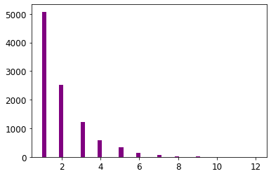

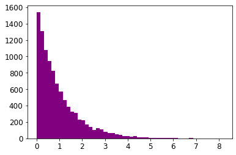

```python
from scipy.stats import geom, expon
geom_distrib=geom(0.5).rvs(10000, random_state=42)
expon_distrib=expon(scale=1).rvs(10000, random_state=42)
plt.hist(geom_distrib, bins=50, color='purple')
plt.show()
plt.hist(expon_distrib, bins=50, color='purple')
plt.show()
```

# Exercise solutions

## 1.

Question: Try a Support Vector Machine regressor (`sklearn.svm.SVR`), with various hyperparameters such as `kernel="linear"` (with various values for the `C` hyperparameter) or `kernel="rbf"` (with various values for the `C` and `gamma` hyperparameters). How does the best `SVR` predictor perform?

```python
from sklearn.model_selection import GridSearchCV

param_grid = [
        {'kernel': ['linear'], 'C': [10., 30., 100., 300., 1000., 3000., 10000., 30000.0]},
        {'kernel': ['rbf'], 'C': [1.0, 3.0, 10., 30., 100., 300., 1000.0],
         'gamma': [0.01, 0.03, 0.1, 0.3, 1.0, 3.0]},
    ]

svm_reg = SVR()
grid_search = GridSearchCV(svm_reg, param_grid, cv=5, scoring='neg_mean_squared_error', verbose=2)
grid_search.fit(clv_prepared, clv_labels)
```

```
Fitting 5 folds for each of 50 candidates, totalling 250 fits
[CV] C=10.0, kernel=linear ...........................................
```

```
[Parallel(n_jobs=1)]: Using backend SequentialBackend with 1 concurrent workers.
```

```
[CV] ............................ C=10.0, kernel=linear, total=   2.8s
[CV] C=10.0, kernel=linear ...........................................
```

```
[Parallel(n_jobs=1)]: Done   1 out of   1 | elapsed:    2.7s remaining:    0.0s
```

[output not shown]

[output cut: 442 more lines]

[output not shown]

```
[Parallel(n_jobs=1)]: Done 250 out of 250 | elapsed: 28.4min finished
```

```
GridSearchCV(cv=5, estimator=SVR(),
             param_grid=[{'C': [10.0, 30.0, 100.0, 300.0, 1000.0, 3000.0,
                                10000.0, 30000.0],
                          'kernel': ['linear']},
                         {'C': [1.0, 3.0, 10.0, 30.0, 100.0, 300.0, 1000.0],
                          'gamma': [0.01, 0.03, 0.1, 0.3, 1.0, 3.0],
                          'kernel': ['rbf']}],
             scoring='neg_mean_squared_error', verbose=2)
```

The best model achieves the following score (evaluated using 5-fold cross validation):

```python
negative_mse = grid_search.best_score_
rmse = np.sqrt(-negative_mse)
rmse
```

```
6667.615052532345
```

```python
grid_search.best_params_
```

```
{'C': 1000.0, 'gamma': 0.1, 'kernel': 'rbf'}
```

## 2.

Question: Try replacing `GridSearchCV` with `RandomizedSearchCV`.

```python
from sklearn.model_selection import RandomizedSearchCV
from scipy.stats import expon, reciprocal

# Note: gamma is ignored when kernel is "linear"
param_distribs = {
        'kernel': ['linear', 'rbf'],
        'C': reciprocal(20, 200000),
        'gamma': expon(scale=1.0),
    }

svm_reg = SVR()
rnd_search = RandomizedSearchCV(svm_reg, param_distributions=param_distribs,
                                n_iter=50, cv=5, scoring='neg_mean_squared_error',
                                verbose=2, random_state=42)
rnd_search.fit(clv_prepared, clv_labels)
```

```
Fitting 5 folds for each of 50 candidates, totalling 250 fits
[CV] C=629.782329591372, gamma=3.010121430917521, kernel=linear ......
```

```
[Parallel(n_jobs=1)]: Using backend SequentialBackend with 1 concurrent workers.
```

```
[CV]  C=629.782329591372, gamma=3.010121430917521, kernel=linear, total=   3.8s
[CV] C=629.782329591372, gamma=3.010121430917521, kernel=linear ......
```

```
[Parallel(n_jobs=1)]: Done   1 out of   1 | elapsed:    3.7s remaining:    0.0s
```

[output not shown]

[output cut: 442 more lines]

[output not shown]

```
[Parallel(n_jobs=1)]: Done 250 out of 250 | elapsed: 98.0min finished
```

```
RandomizedSearchCV(cv=5, estimator=SVR(), n_iter=50,
                   param_distributions={'C': <scipy.stats._distn_infrastructure.rv_frozen object at 0x0000027A385EE550>,
                                        'gamma': <scipy.stats._distn_infrastructure.rv_frozen object at 0x0000027A39FCC760>,
                                        'kernel': ['linear', 'rbf']},
                   random_state=42, scoring='neg_mean_squared_error',
                   verbose=2)
```

The best model achieves the following score (evaluated using 5-fold cross validation):

```python
negative_mse = rnd_search.best_score_
rmse = np.sqrt(-negative_mse)
rmse
```

```
5971.478452035043
```

Now this is closer to the performance of the `RandomForestRegressor` (but not quite there yet). Let's check the best hyperparameters found:

```python
rnd_search.best_params_
```

```
{'C': 24547.601975705915, 'gamma': 0.22153944050588595, 'kernel': 'rbf'}
```

This time the search found a good set of hyperparameters for the RBF kernel. Randomized search tends to find better hyperparameters than grid search in the same amount of time.

Let's look at the exponential distribution we used, with `scale=1.0`. Note that some samples are much larger or smaller than 1.0, but when you look at the log of the distribution, you can see that most values are actually concentrated roughly in the range of exp(-2) to exp(+2), which is about 0.1 to 7.4.

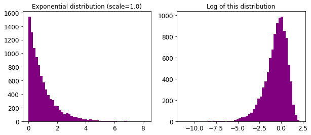

```python
expon_distrib = expon(scale=1.)
samples = expon_distrib.rvs(10000, random_state=42)
plt.figure(figsize=(10, 4))
plt.subplot(121)
plt.title("Exponential distribution (scale=1.0)")
plt.hist(samples, bins=50, color='purple')
plt.subplot(122)
plt.title("Log of this distribution")
plt.hist(np.log(samples), bins=50, color='purple')
plt.show()
```

The distribution we used for `C` looks quite different: the scale of the samples is picked from a uniform distribution within a given range, which is why the right graph, which represents the log of the samples, looks roughly constant. This distribution is useful when you don't have a clue of what the target scale is:

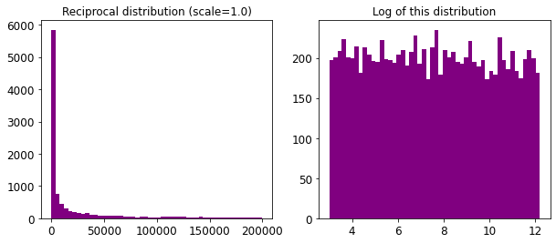

```python
reciprocal_distrib = reciprocal(20, 200000)
samples = reciprocal_distrib.rvs(10000, random_state=42)
plt.figure(figsize=(10, 4))
plt.subplot(121)
plt.title("Reciprocal distribution (scale=1.0)")
plt.hist(samples, bins=50, color='purple')
plt.subplot(122)
plt.title("Log of this distribution")
plt.hist(np.log(samples), bins=50, color='purple')
plt.show()
```

The reciprocal distribution is useful when you have no idea what the scale of the hyperparameter should be (indeed, as you can see on the figure on the right, all scales are equally likely, within the given range), whereas the exponential distribution is best when you know (more or less) what the scale of the hyperparameter should be.

## 3.

Question: Try adding a transformer in the preparation pipeline to select only the most important attributes.

```python
from sklearn.base import BaseEstimator, TransformerMixin

def indices_of_top_k(arr, k):
    return np.sort(np.argpartition(np.array(arr), -k)[-k:])

class TopFeatureSelector(BaseEstimator, TransformerMixin):
    def __init__(self, feature_importances, k):
        self.feature_importances = feature_importances
        self.k = k
    def fit(self, X, y=None):
        self.feature_indices_ = indices_of_top_k(self.feature_importances, self.k)
        return self
    def transform(self, X):
        return X[:, self.feature_indices_]
```

Let's define the number of top features we want to keep:

```python
k = 5
```

Now let's look for the indices of the top k features:

```python
top_k_feature_indices = indices_of_top_k(feature_importances, k)
top_k_feature_indices
```

```
array([1, 2, 3, 5, 6], dtype=int64)
```

```python
np.array(attributes)[top_k_feature_indices]
```

```
array(['Monthly Premium Auto', 'Months Since Last Claim',
       'Months Since Policy Inception', 'Number of Policies',
       'Total Claim Amount'], dtype='<U29')
```

Let's double check that these are indeed the top k features:

```python
sorted(zip(feature_importances, attributes), reverse=True)[:k]
```

```
[(0.48283125253950154, 'Number of Policies'),
 (0.19392527901915588, 'Monthly Premium Auto'),
 (0.05212980106602623, 'Total Claim Amount'),
 (0.040324857656676046, 'Months Since Last Claim'),
 (0.032857204857564, 'Months Since Policy Inception')]
```

Now let's create a new pipeline that runs the previously defined preparation pipeline, and adds top k feature selection:

```python
preparation_and_feature_selection_pipeline = Pipeline([
    ('preparation', full_pipeline),
    ('feature_selection', TopFeatureSelector(feature_importances, k))
])
```

```python
clv_prepared_top_k_features = preparation_and_feature_selection_pipeline.fit_transform(clv)
```

Let's look at the features of the first 3 instances:

```python
clv_prepared_top_k_features[0:3]
```

```
array([[ 0.37038052, -0.4057551 , -0.63946852, -0.82431423,  0.25927703],
       [ 0.66058924, -0.90184849, -0.13744365, -0.82431423,  1.12848853],
       [-0.64535   , -1.29872321,  0.04185095,  1.66463786, -0.60548386]])
```

Now let's double check that these are indeed the top k features:

```python
clv_prepared[0:3, top_k_feature_indices]
```

```
array([[ 0.37038052, -0.4057551 , -0.63946852, -0.82431423,  0.25927703],
       [ 0.66058924, -0.90184849, -0.13744365, -0.82431423,  1.12848853],
       [-0.64535   , -1.29872321,  0.04185095,  1.66463786, -0.60548386]])
```

Works great! :)

## 4.

Question: Try creating a single pipeline that does the full data preparation plus the final prediction.

```python
prepare_select_and_predict_pipeline = Pipeline([
    ('preparation', full_pipeline),
    ('feature_selection', TopFeatureSelector(feature_importances, k)),
    ('forest_reg', forest_reg) #I used the grid_search rather than the rnd_search because rnd_search was not working
])
```

```python
prepare_select_and_predict_pipeline.fit(clv, clv_labels)
```

```
Pipeline(steps=[('preparation',
                 ColumnTransformer(transformers=[('num',
                                                  Pipeline(steps=[('imputer',
                                                                   SimpleImputer(fill_value=0,
                                                                                 strategy='constant')),
                                                                  ('std_scaler',
                                                                   StandardScaler())]),
                                                  ['Income',
                                                   'Monthly Premium Auto',
                                                   'Months Since Last Claim',
                                                   'Months Since Policy '
                                                   'Inception',
                                                   'Number of Open Complaints',
                                                   'Number of Policies',
                                                   'Total Claim Amount']),
                                                 ('cat', OneHotEncoder...
       0.00095503, 0.00112948, 0.00098169, 0.0016607 , 0.00219064,
       0.00295614, 0.00381386, 0.00054714, 0.00061053, 0.00119699,
       0.00393213, 0.00467157, 0.00262787, 0.00326658, 0.00452425,
       0.0040668 , 0.00376745, 0.00250047, 0.00580408, 0.00422795,
       0.00885055, 0.0043148 , 0.00229631, 0.00450205, 0.00277313,
       0.00356613, 0.00318143]),
                                    k=5)),
                ('forest_reg', RandomForestRegressor(random_state=42))])
```

Let's try the full pipeline on a few instances:

```python
some_data = clv.iloc[:4]
some_labels = clv_labels.iloc[:4]

print("Predictions:\t", prepare_select_and_predict_pipeline.predict(some_data))
print("Labels:\t\t", list(some_labels))
```

```
Predictions:	 [4146.86033224 4494.65601735 5741.8069432  3472.28904694]
Labels:		 [4233.56878, 4514.247472999999, 5789.8509, 3304.758268]
```

Well, the full pipeline seems to work fine. I used `RandomForestRegressor` which provided better predictions than `SVR`.

## 5.

Question: Automatically explore some preparation options using `GridSearchCV`.

```python
param_grid = [{
    'preparation__num__imputer__strategy': ['mean', 'median', 'most_frequent'],
    'feature_selection__k': list(range(1, len(feature_importances) + 1))
}]

grid_search_prep = GridSearchCV(prepare_select_and_predict_pipeline, param_grid, cv=5,
                                scoring='neg_mean_squared_error', verbose=2)
grid_search_prep.fit(clv, clv_labels)
```

```
Fitting 5 folds for each of 186 candidates, totalling 930 fits
[CV] feature_selection__k=1, preparation__num__imputer__strategy=mean
[CV]  feature_selection__k=1, preparation__num__imputer__strategy=mean, total=   0.2s
[CV] feature_selection__k=1, preparation__num__imputer__strategy=mean
```

```
[Parallel(n_jobs=1)]: Using backend SequentialBackend with 1 concurrent workers.
[Parallel(n_jobs=1)]: Done   1 out of   1 | elapsed:    0.1s remaining:    0.0s
```

[output not shown]

[output cut: 1802 more lines]

[output not shown]

```
[Parallel(n_jobs=1)]: Done 930 out of 930 | elapsed: 73.3min finished
```

```
GridSearchCV(cv=5,
             estimator=Pipeline(steps=[('preparation',
                                        ColumnTransformer(transformers=[('num',
                                                                         Pipeline(steps=[('imputer',
                                                                                          SimpleImputer(fill_value=0,
                                                                                                        strategy='constant')),
                                                                                         ('std_scaler',
                                                                                          StandardScaler())]),
                                                                         ['Income',
                                                                          'Monthly '
                                                                          'Premium '
                                                                          'Auto',
                                                                          'Months '
                                                                          'Since '
                                                                          'Last '
                                                                          'Claim',
                                                                          'Months '
                                                                          'Since '
                                                                          'Policy '
                                                                          'Inception',
                                                                          'Number '
                                                                          'of '
                                                                          'Open '
                                                                          'Complaints',
                                                                          'Number '
                                                                          'of '...
       0.00885055, 0.0043148 , 0.00229631, 0.00450205, 0.00277313,
       0.00356613, 0.00318143]),
                                                           k=5)),
                                       ('forest_reg',
                                        RandomForestRegressor(random_state=42))]),
             param_grid=[{'feature_selection__k': [1, 2, 3, 4, 5, 6, 7, 8, 9,
                                                   10, 11, 12, 13, 14, 15, 16,
                                                   17, 18, 19, 20, 21, 22, 23,
                                                   24, 25, 26, 27, 28, 29, 30, ...],
                          'preparation__num__imputer__strategy': ['mean',
                                                                  'median',
                                                                  'most_frequent']}],
             scoring='neg_mean_squared_error', verbose=2)
```

```python
grid_search_prep.best_params_
```

```
{'feature_selection__k': 34,
 'preparation__num__imputer__strategy': 'most_frequent'}
```

The best imputer strategy is `most_frequent` and apparently `34 features` are useful.

**END** - Thank You! :)